# Statistics_Lecture1

## Load libraries

```r
library(ggplot2)
```

## Mutation / disease analysis

```r
# This table represents DNA mutations that occurred in individuals who did or did not have a (fictional) disease
#                Disease     No disease
#   Mutation     33          210
#   No mutation  125         507
contingencyTable <- matrix(c(33, 125, 210, 507), nrow=2)

# Perform chi-squared goodness-of-fit test
chisq.test(contingencyTable)
```

```
##
##  Pearson's Chi-squared test with Yates' continuity correction
##
## data:  contingencyTable
## X-squared = 4.1479, df = 1, p-value = 0.04169
```

```r
# This table represents DNA mutations that occurred in individuals who did or did not have a (fictional) disease
#                Disease     No disease
#   Mutation     3           30
#   No mutation  128         498
contingencyTable <- matrix(c(3, 128, 30, 498), nrow=2)

# We cannot use the chi-square test because one of the cells in the above table has a number smaller than 5, so
# we will use Fisher's exact test as an alternative.
fisher.test(contingencyTable)
```

```
##
##  Fisher's Exact Test for Count Data
##
## data:  contingencyTable
## p-value = 0.1225
## alternative hypothesis: true odds ratio is not equal to 1
## 95 percent confidence interval:
##  0.07488142 1.28320872
## sample estimates:
## odds ratio
##   0.389471
```

## Protein expression - correlation - examples

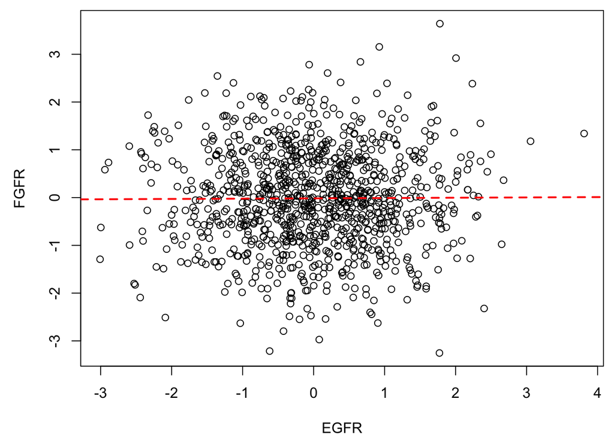

```r
# Generate random values
set.seed(1)
egfr <- rnorm(1000)
fgfr <- rnorm(1000)

# Change the margins around the plot
par(mar=c(4.1, 4.6, 0.6, 0.6))

plot(egfr, fgfr, main="", xlab="EGFR", ylab="FGFR")
abline(lm(fgfr~egfr), col="red", lty=2, lwd=2)
```

```r
# Calculate correlation
cor(egfr, fgfr, method="pearson")
```

```
## [1] 0.006401211
```

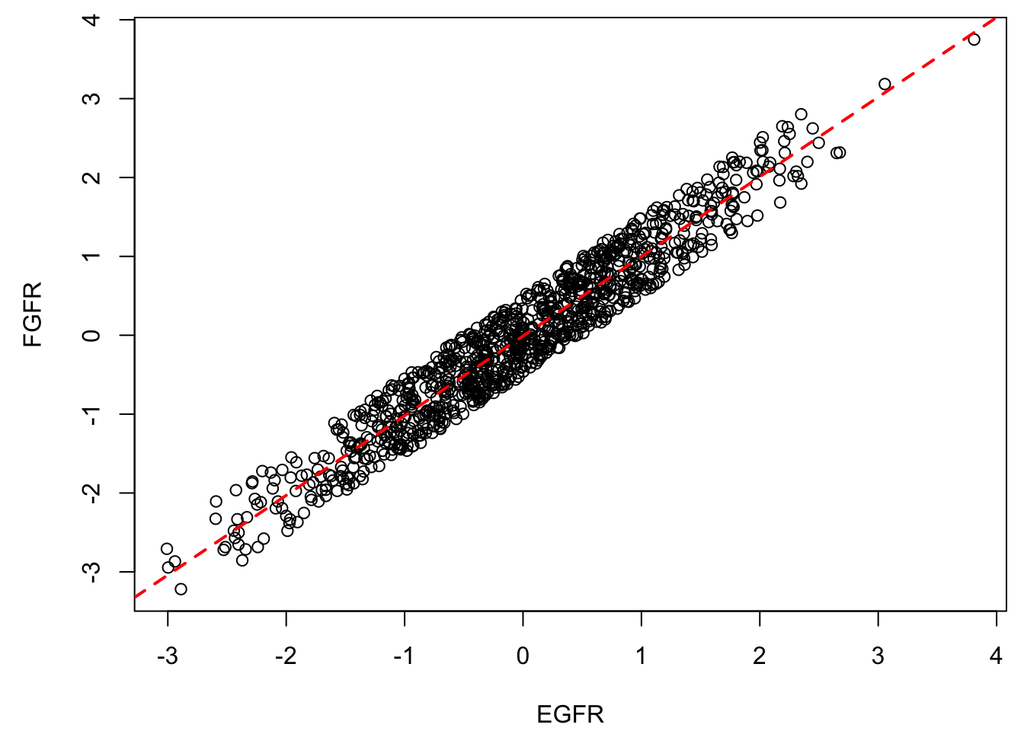

```r
# Generate random values that are strongly positively correlated with each other
set.seed(1)
egfr <- rnorm(1000)
fgfr <- jitter(egfr, amount=0.5)

# Change the margins around the plot
par(mar=c(4.1, 4.6, 0.6, 0.6))

plot(egfr, fgfr, main="", xlab="EGFR", ylab="FGFR")
abline(lm(fgfr~egfr), col="red", lty=2, lwd=2)
```

```r
# Calculate correlation
cor(egfr, fgfr, method="pearson")
```

```
## [1] 0.9633502
```

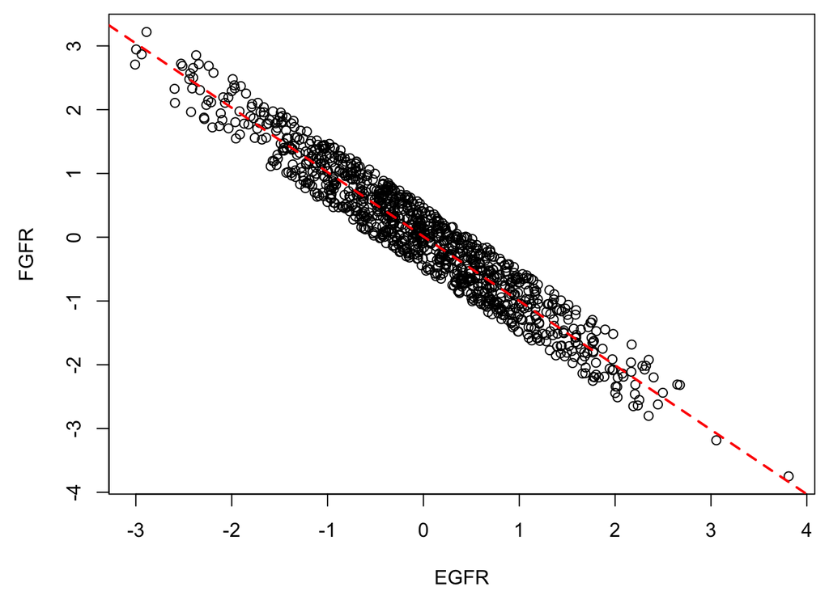

```r
# Generate random values that are strongly negatively correlated with each other
set.seed(1)
egfr <- rnorm(1000)
fgfr <- -jitter(egfr, amount=0.5)

# Change the margins around the plot
par(mar=c(4.1, 4.6, 0.6, 0.6))

plot(egfr, fgfr, main="", xlab="EGFR", ylab="FGFR")
abline(lm(fgfr~egfr), col="red", lty=2, lwd=2)
```

```r
# Calculate correlation
cor(egfr, fgfr, method="pearson")
```

```
## [1] -0.9633502
```

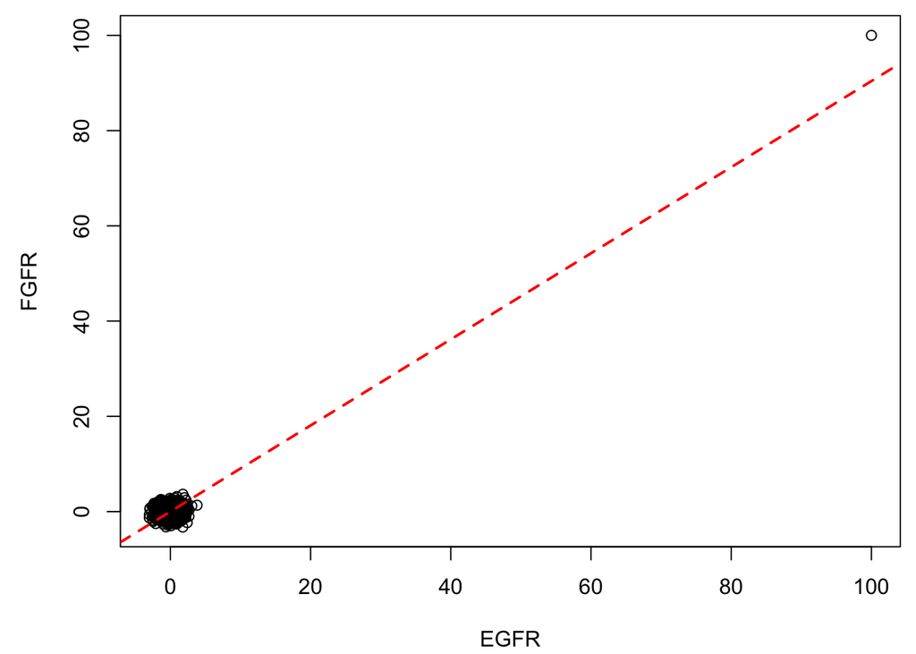

```r
# Generate values that are not strongly correlated but with a strong outlier
set.seed(1)
egfr <- c(rnorm(1000), 100)
fgfr <- c(rnorm(1000), 100)

# Change the margins around the plot
par(mar=c(4.1, 4.6, 0.6, 0.6))

plot(egfr, fgfr, main="", xlab="EGFR", ylab="FGFR")
abline(lm(fgfr~egfr), col="red", lty=2, lwd=2)
```

```r
# Calculate correlation
cor(egfr, fgfr, method="pearson")
```

```
## [1] 0.9034746
```

```r
cor(egfr, fgfr, method="spearman")
```

```
## [1] -0.007270813
```

## Principal component analysis (PCA) of `iris` data

Look at the first few rows of the `iris` data.

```r
head(iris)
```

```
##   Sepal.Length Sepal.Width Petal.Length Petal.Width Species
## 1          5.1         3.5          1.4         0.2  setosa
## 2          4.9         3.0          1.4         0.2  setosa
## 3          4.7         3.2          1.3         0.2  setosa
## 4          4.6         3.1          1.5         0.2  setosa
## 5          5.0         3.6          1.4         0.2  setosa
## 6          5.4         3.9          1.7         0.4  setosa
```

Create a new variable that excludes the Species name. When evaluating the principal components, we only want to use the numeric data.

```r
irisData <- iris[,-5] # A negative sign excludes the specified column
head(irisData)
```

```
##   Sepal.Length Sepal.Width Petal.Length Petal.Width
## 1          5.1         3.5          1.4         0.2
## 2          4.9         3.0          1.4         0.2
## 3          4.7         3.2          1.3         0.2
## 4          4.6         3.1          1.5         0.2
## 5          5.0         3.6          1.4         0.2
## 6          5.4         3.9          1.7         0.4
```

Derive the principal components. Also tell it to scale each variable to have “unit variance” (mean of 0 and variance of 1). This is usually a good idea when working with *continuous* values.

```r
pcIrisData <- prcomp(irisData, scale=TRUE)
head(pcIrisData)
```

```
## $sdev
## [1] 1.7083611 0.9560494 0.3830886 0.1439265
##
## $rotation
##                     PC1         PC2        PC3        PC4
## Sepal.Length  0.5210659 -0.37741762  0.7195664  0.2612863
## Sepal.Width  -0.2693474 -0.92329566 -0.2443818 -0.1235096
## Petal.Length  0.5804131 -0.02449161 -0.1421264 -0.8014492
## Petal.Width   0.5648565 -0.06694199 -0.6342727  0.5235971
##
## $center
## Sepal.Length  Sepal.Width Petal.Length  Petal.Width
##     5.843333     3.057333     3.758000     1.199333
##
## $scale
```

[output cut: 155 more lines]

Plot the percent of variance explained by each principal component. The first and second principal components explain most of the variance.

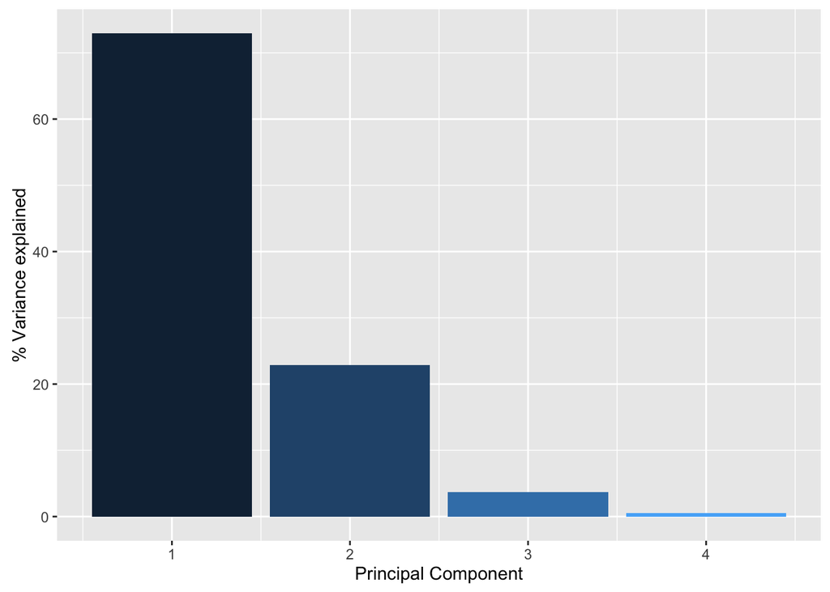

```r
# Calculate the percent of variance explained
percentVE <- 100 * pcIrisData$sdev^2 / sum(pcIrisData$sdev^2)

# Create a data frame object that holds these data (ggplot2 can only work with data frames)
# Also add a column that indicates the number/name of each principal component
percentVEDataFrame <- data.frame(PC=1:4, PercentExplained=percentVE)

ggplot(percentVEDataFrame, aes(PC, PercentExplained, fill=PC)) +
  geom_bar(stat="identity") +
  xlab("Principal Component") +
  ylab("% Variance explained") +
  theme(legend.position="none") # Remove the legend
```

Plot the first two principal components against each other. Color these values by the species type. This shows that the first two principal component values correlate closely with the species type.

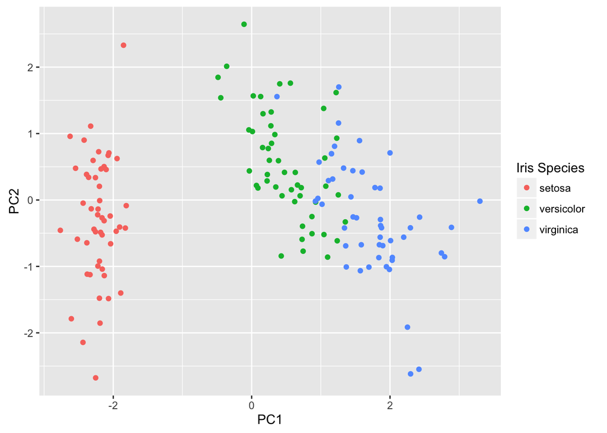

```r
# Extract the principal component values and convert it to a data frame (ggplot2 can only work with data frames)
pcIrisDataFrame <- as.data.frame(pcIrisData$x)

ggplot(pcIrisDataFrame, aes(x=PC1, y=PC2)) +
  geom_point(aes(col=iris$Species)) +
  labs(col = "Iris Species") # This changes the legend title
```

Plot the rotation matrix. These are the values that were used to transform (using linear algebra) the original data values to the principal component values. Looking at these helps in understanding which variables influence which principal components.

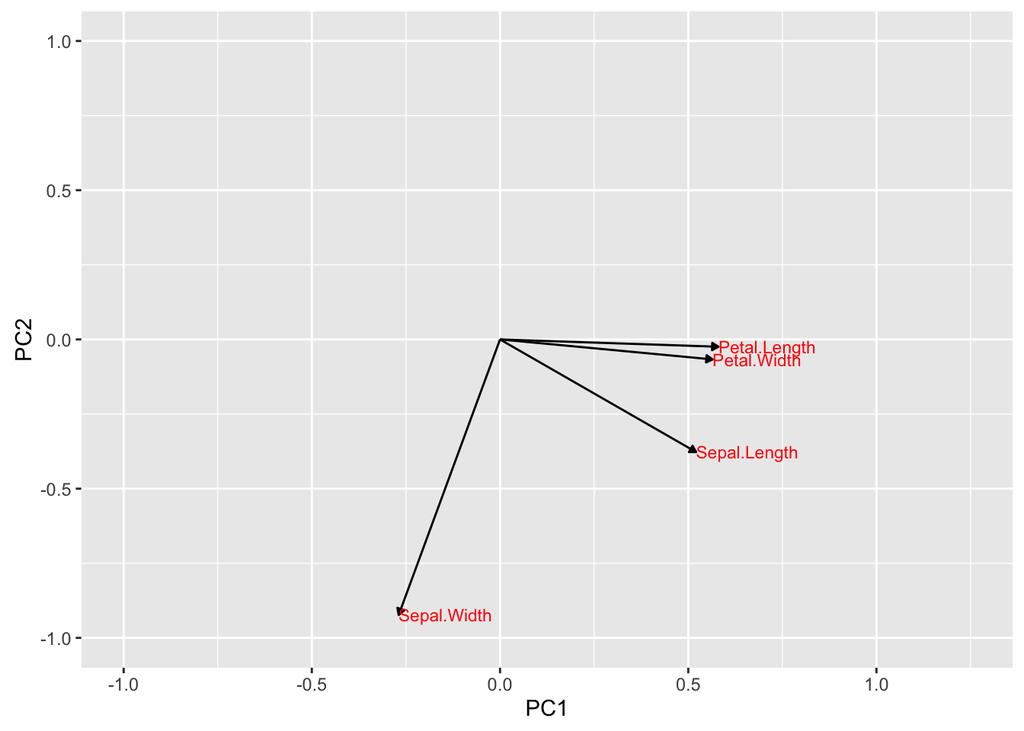

```r
library(ggplot2)
library(grid)

rotation_data <- data.frame(pcIrisData$rotation, variable=row.names(pcIrisData$rotation))

arrow_style <- arrow(length = unit(0.05, "inches"), type = "closed")

ggplot(rotation_data) +
  geom_segment(aes(xend=PC1, yend=PC2), x=0, y=0, arrow=arrow_style) +
  geom_text(aes(x=PC1, y=PC2, label=variable), hjust=0, size=3, color='red') +
  xlim(-1.,1.25) +
  ylim(-1.,1.)# +
```

```r
  #coord_fixed() # fix aspect ratio to 1:1
```

Alternatively, we could use principal component analysis to understand the relationships among variables, rather than the relationionships among the species. To do this, we would first need to “transpose” the data matrix (turn it on its side). This makes it so the variables are the rows, and the samples are the columns. But first we need to scale the data to have unit variance. In the example above, this was done by the `prcomp` function. However, here will do it separately so the data will be scaled the same way they were scaled in the previous example.

```r
irisDataScaled <- scale(irisData)

# Transpose the data matrix
irisDataTransposed <- t(irisDataScaled)

head(irisDataTransposed)
```

```
##                    [,1]       [,2]       [,3]        [,4]      [,5]
## Sepal.Length -0.8976739 -1.1392005 -1.3807271 -1.50149039 -1.018437
## Sepal.Width   1.0156020 -0.1315388  0.3273175  0.09788935  1.245030
## Petal.Length -1.3357516 -1.3357516 -1.3923993 -1.27910398 -1.335752
## Petal.Width  -1.3110521 -1.3110521 -1.3110521 -1.31105215 -1.311052
##                   [,6]       [,7]       [,8]      [,9]       [,10]
## Sepal.Length -0.535384 -1.5014904 -1.0184372 -1.743017 -1.13920048
## Sepal.Width   1.933315  0.7861738  0.7861738 -0.360967  0.09788935
## Petal.Length -1.165809 -1.3357516 -1.2791040 -1.335752 -1.27910398
## Petal.Width  -1.048667 -1.1798595 -1.3110521 -1.311052 -1.44224482
##                  [,11]      [,12]      [,13]      [,14]       [,15]
## Sepal.Length -0.535384 -1.2599638 -1.2599638 -1.8637803 -0.05233076
## Sepal.Width   1.474458  0.7861738 -0.1315388 -0.1315388  2.16274279
## Petal.Length -1.279104 -1.2224563 -1.3357516 -1.5056946 -1.44904694
## Petal.Width  -1.311052 -1.3110521 -1.4422448 -1.4422448 -1.31105215
##                   [,16]     [,17]      [,18]      [,19]      [,20]
## Sepal.Length -0.1730941 -0.535384 -0.8976739 -0.1730941 -0.8976739
## Sepal.Width   3.0804554  1.933315  1.0156020  1.7038865  1.7038865
## Petal.Length -1.2791040 -1.392399 -1.3357516 -1.1658087 -1.2791040
## Petal.Width  -1.0486668 -1.048667 -1.1798595 -1.1798595 -1.1798595
##                   [,21]      [,22]     [,23]      [,24]      [,25]
## Sepal.Length -0.5353840 -0.8976739 -1.501490 -0.8976739 -1.2599638
## Sepal.Width   0.7861738  1.4744583  1.245030  0.5567457  0.7861738
## Petal.Length -1.1658087 -1.2791040 -1.562342 -1.1658087 -1.0525134
## Petal.Width  -1.3110521 -1.0486668 -1.311052 -0.9174741 -1.3110521
##                   [,26]      [,27]      [,28]      [,29]      [,30]
## Sepal.Length -1.0184372 -1.0184372 -0.7769106 -0.7769106 -1.3807271
## Sepal.Width  -0.1315388  0.7861738  1.0156020  0.7861738  0.3273175
## Petal.Length -1.2224563 -1.2224563 -1.2791040 -1.3357516 -1.2224563
## Petal.Width  -1.3110521 -1.0486668 -1.3110521 -1.3110521 -1.3110521
##                    [,31]      [,32]      [,33]      [,34]       [,35]
## Sepal.Length -1.25996379 -0.5353840 -0.7769106 -0.4146207 -1.13920048
## Sepal.Width   0.09788935  0.7861738  2.3921710  2.6215991  0.09788935
## Petal.Length -1.22245633 -1.2791040 -1.2791040 -1.3357516 -1.27910398
## Petal.Width  -1.31105215 -1.0486668 -1.4422448 -1.3110521 -1.31105215
##                   [,36]      [,37]     [,38]      [,39]      [,40]
## Sepal.Length -1.0184372 -0.4146207 -1.139200 -1.7430170 -0.8976739
## Sepal.Width   0.3273175  1.0156020  1.245030 -0.1315388  0.7861738
## Petal.Length -1.4490469 -1.3923993 -1.335752 -1.3923993 -1.2791040
## Petal.Width  -1.3110521 -1.3110521 -1.442245 -1.3110521 -1.3110521
```

[output cut: 95 more lines]

```
##                 [,137]     [,138]     [,139]     [,140]     [,141]
## Sepal.Length 0.5514857 0.67224905  0.1891958 1.27606556 1.03453895
## Sepal.Width  0.7861738 0.09788935 -0.1315388 0.09788935 0.09788935
## Petal.Length 1.0434497 0.98680210  0.5902685 0.93015445 1.04344975
## Petal.Width  1.5751867 0.78803068  0.7880307 1.18160871 1.57518674
##                  [,142]      [,143]    [,144]    [,145]     [,146]
## Sepal.Length 1.27606556 -0.05233076 1.1553023 1.0345390  1.0345390
## Sepal.Width  0.09788935 -0.81982329 0.3273175 0.5567457 -0.1315388
## Petal.Length 0.76021149  0.76021149 1.2133927 1.1000974  0.8168591
## Petal.Width  1.44399406  0.91922335 1.4439941 1.7063794  1.4439941
##                  [,147]     [,148]    [,149]      [,150]
## Sepal.Length  0.5514857  0.7930124 0.4307224  0.06843254
## Sepal.Width  -1.2786796 -0.1315388 0.7861738 -0.13153881
## Petal.Length  0.7035638  0.8168591 0.9301544  0.76021149
## Petal.Width   0.9192234  1.0504160 1.4439941  0.78803068
```

Now we can apply code that is similar to what we applied previously. This suggests that petal length and petal width contribute similarly to the variance in the data (because they are clustered together on the plot), and it suggests that sepal length and width are fairly independent of each other and of the other attributes (because they are spread out on the plot).

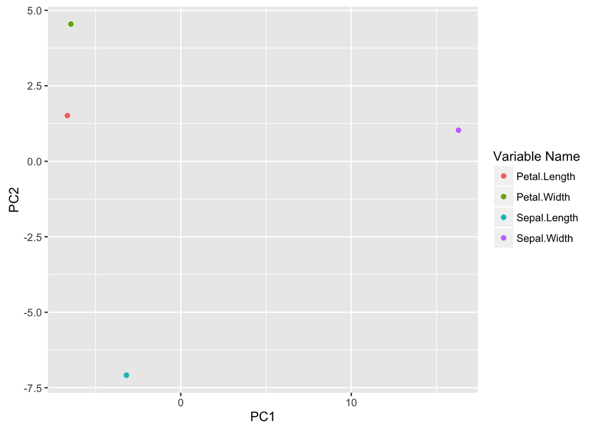

```r
# Derive the principal components
pcIrisData2 <- prcomp(irisDataTransposed, scale=TRUE)

# Create a data frame
pcIrisDataFrame2 <- as.data.frame(pcIrisData2$x)

ggplot(pcIrisDataFrame2, aes(x=PC1, y=PC2)) +
  geom_point(aes(col=colnames(irisData))) +
  labs(col = "Variable Name") # This changes the legend title
```